# Webinar

October 28, 2015

## Objectives

- Policy Simulator
  - Agents Flexibility
  - Model Flexibility
- Policy Optimization

## The State of the Art

- Random Utility Models
  - Statistically Efficient
  - Easily Generalizable
  - Policy-Brittle
- Dynamic Programming
  - Strongly Rational
  - Computationally Expensive
  - Ad hoc

## The One Agent Problem

- Find the most profitable spot to fish
- Constraints:
  - No biomass information
  - Environment changes over time
- Subproblems:
  - How to explore
  - Explore-Exploit Tradeoff

## Fast and Frugal Adaptation

- How to explore
  - Tow at a nearby cell from subjective best
  - Random Hill-Climbing
- When to explore
  - Stochastically choose to explore next trip with probability \(p\)
  - Adjust \(p\) if exploration is often (un)succesful
- Why not more nuanced bandit algorithms?
- Why not interview grounded algorithms?

## One Agent world

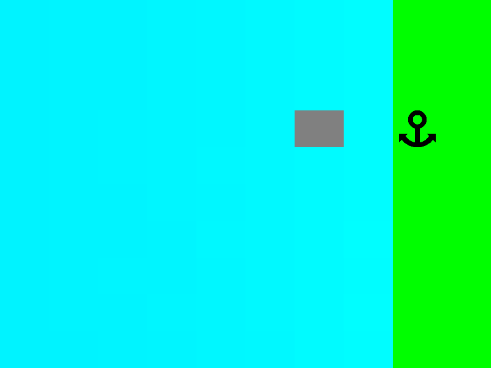

## One Agent sample run

[video not shown]

## Multiple Agents

- Other boats consume biomass
- You can use other boats information
- How to imitate?
- With probability \(p\) explore, with probability \(i\) ask a friend otherwise exploit

## Two Agents sample run

[video not shown]

## Many Agents

[video not shown]

## Imitation-Exploration Tradeoff

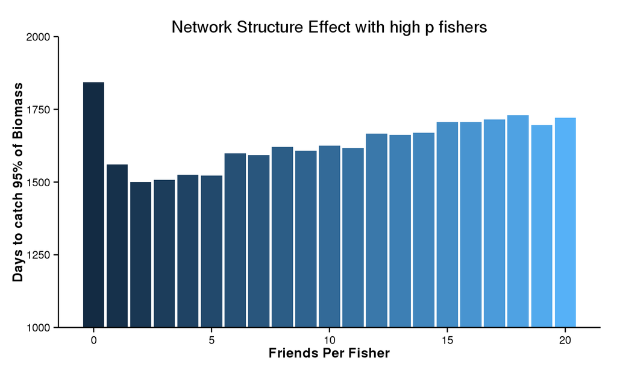

## Imitation-Exploration Tradeoff

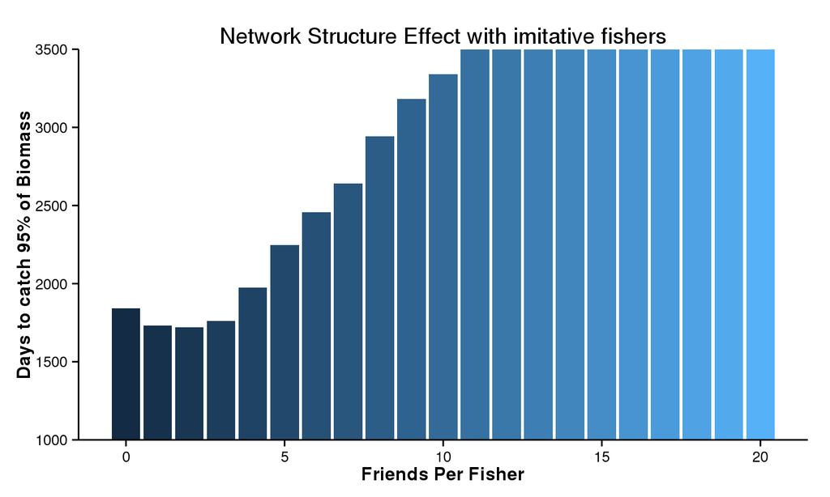

## Oil Prices

[video not shown]

## What information they have and they act on

- Associate a choice with profits (per trip or per month)
- Compare and imitate profits
- Proceed by feedback and trial and error

## Fish the Line (part 1)

[video not shown]

## Fish the Line (part 2)

[video not shown]

## Fish the Rocky Line (part 1)

[video not shown]

## Fish the Rocky Line (part 2)

[video not shown]

## Not Just Locational Choices

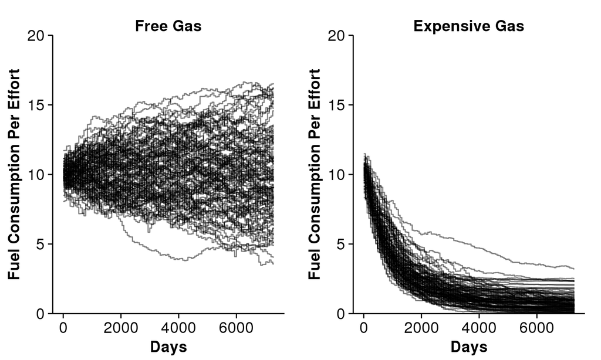

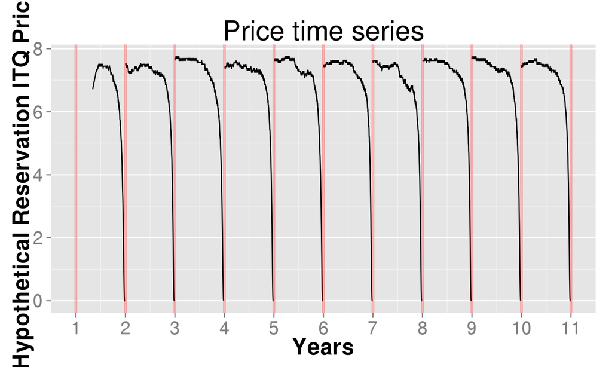

## Single Species TAC vs ITQ

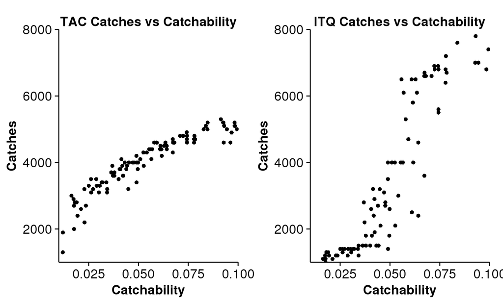

## Single Species TAC vs ITQ (mileage)

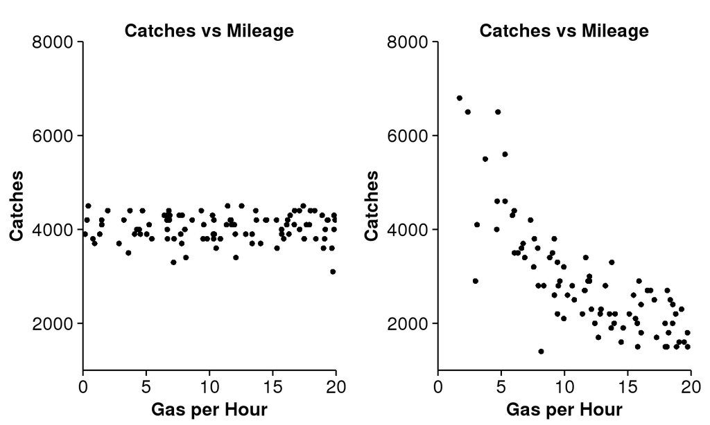

## Seventy-Thirty World

[video not shown]

## ITQ Prices

- Quotas are distributed 90% reds, 10% blue

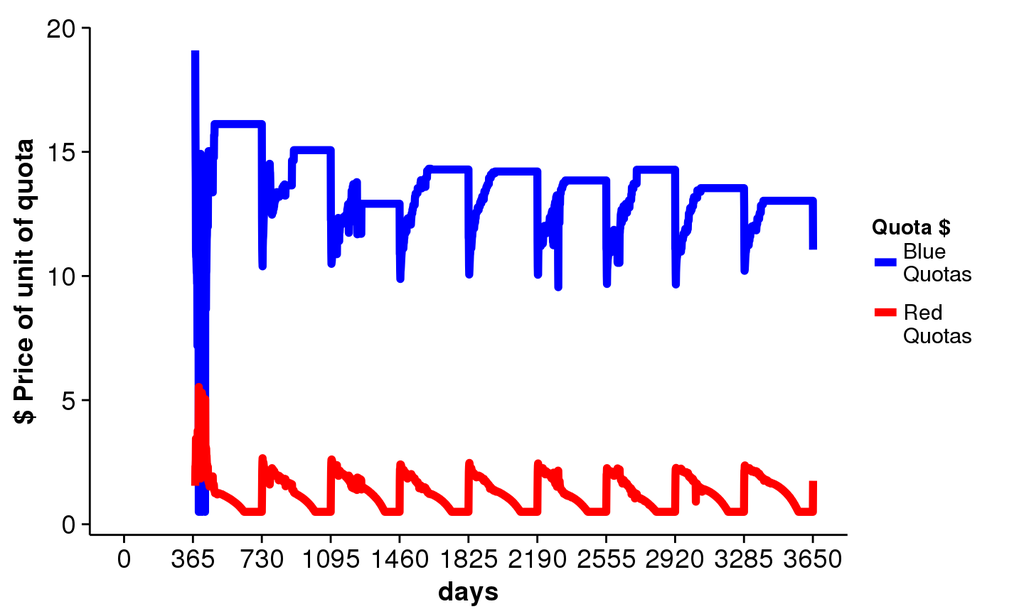

## Blues are choke species

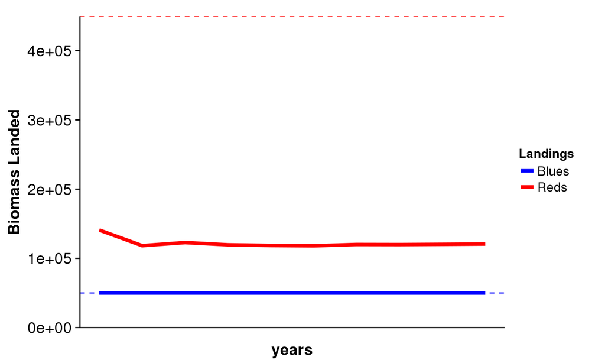

## ITQ drives Gear (start)

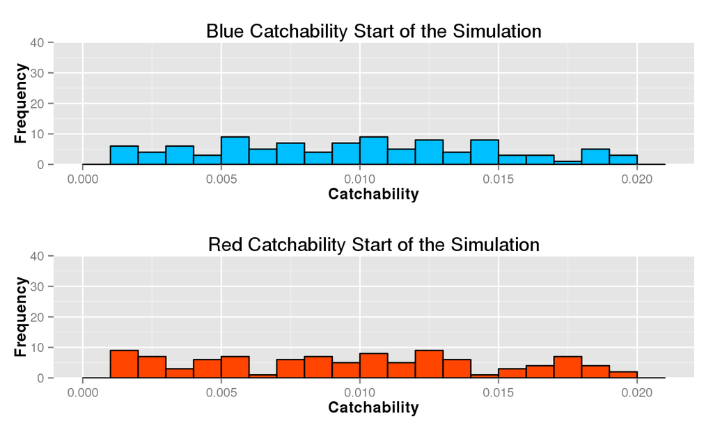

## ITQ drives Gear (end)

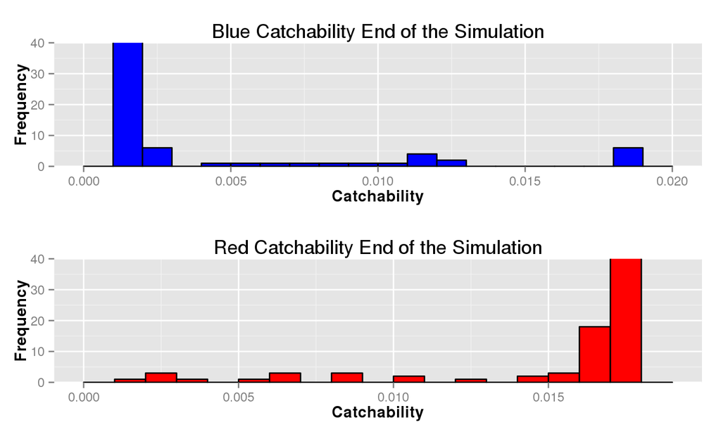

## Gear fixes wastes

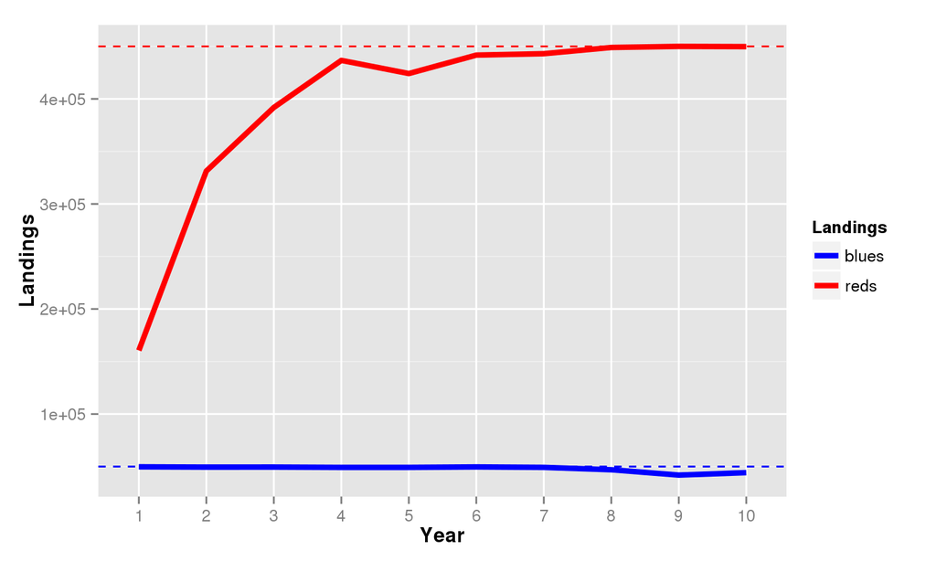

## North-South world

[video not shown]

## Location choices

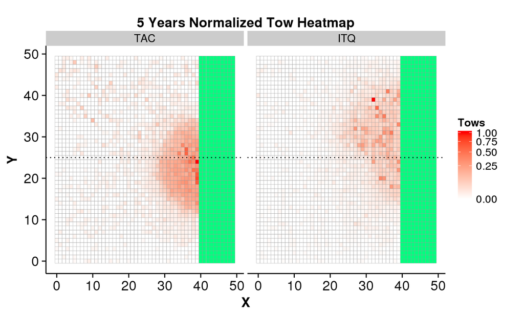

## ITQ incentivates geography

[video not shown]

## What's next

- Package this data-free version
- Move towards more realism
  - 5 Species World
  - PDRA2
- More visible testing